# native_late_adipoDE

## Annnotate with gene names

```r
mart <- biomaRt::useMart(biomart = "ensembl",
  dataset = "hsapiens_gene_ensembl",
  host = "jan2019.archive.ensembl.org")
annot = getBM(c("external_gene_name", "description", "ensembl_gene_id", "gene_biotype"),
              filters = "ensembl_gene_id",
              values = as.character(filt$genes$Geneid),
              mart = mart,
              useCache = F)
head(annot)
```

```
##   external_gene_name
## 1                FGR
## 2              STPG1
## 3             NIPAL3
## 4                AK2
## 5              KDM1A
## 6               ST7L
##                                                                         description
## 1 FGR proto-oncogene, Src family tyrosine kinase [Source:HGNC Symbol;Acc:HGNC:3697]
## 2        sperm tail PG-rich repeat containing 1 [Source:HGNC Symbol;Acc:HGNC:28070]
## 3                 NIPA like domain containing 3 [Source:HGNC Symbol;Acc:HGNC:25233]
## 4                              adenylate kinase 2 [Source:HGNC Symbol;Acc:HGNC:362]
## 5                         lysine demethylase 1A [Source:HGNC Symbol;Acc:HGNC:29079]
## 6          suppression of tumorigenicity 7 like [Source:HGNC Symbol;Acc:HGNC:18441]
##   ensembl_gene_id   gene_biotype
## 1 ENSG00000000938 protein_coding
## 2 ENSG00000001460 protein_coding
## 3 ENSG00000001461 protein_coding
## 4 ENSG00000004455 protein_coding
## 5 ENSG00000004487 protein_coding
## 6 ENSG00000007341 protein_coding
```

```r
#Tidying up the annot table
annot$description = gsub("\\[Source:.+\\]", "", annot$description)
colnames(annot)[1] = "gene_name"
colnames(annot)[3] = "gene"

#Add gene names to data object
filt$genes = merge(filt$genes, annot, by.x= "Geneid",
                        by.y = "gene", sort=FALSE)
colnames(filt$genes) = c("gene","length","gene_name","description","gene_biotype")
head(filt$genes)
```

```
##              gene length  gene_name
## 1 ENSG00000227232   1351     WASH7P
## 2 ENSG00000237613   1219    FAM138A
## 3 ENSG00000238009   3726 AL627309.1
## 4 ENSG00000241860   6195 AL627309.5
## 5 ENSG00000279928    570 FO538757.1
## 6 ENSG00000279457   1397     WASH9P
##                                     description           gene_biotype
## 1     WAS protein family homolog 7, pseudogene  unprocessed_pseudogene
## 2 family with sequence similarity 138 member A                 lincRNA
## 3                              novel transcript                lincRNA
## 4                                                 processed_transcript
## 5     DEAD/H-box helicase 11 (DDX11) pseudogene unprocessed_pseudogene
## 6     WAS protein family homolog 9, pseudogene  unprocessed_pseudogene
```

### usually make FPKM tables here

but I’m going to hold off until I can check out the normalisation

## Limma DE

Well the limma mean variance trend looks fine :)

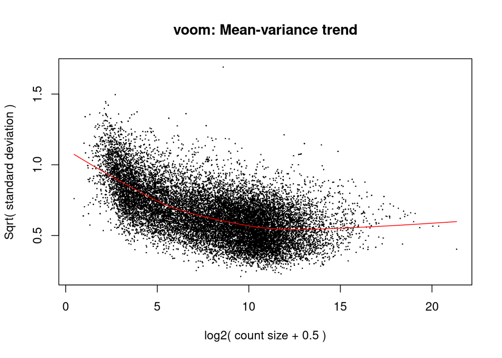

```r
filt$samples$group = factor(filt$samples$group)
norm_ob = voom(filt, plot=T)
```

### Simple separate design

Hmm that’s a lot of different genes, quite the lenient test. I don’t trust this with the normalisation differences. Oh and when we set the threshold lower donor13 effect is gone, and the total effect is driven by the donor7.

```r
design = model.matrix(~0+norm_ob$targets$group)
colnames(design) = levels(norm_ob$targets$group)
design
```

```
##    D07G D07G.floating D13A D13A.floating
## 1     0             1    0             0
## 2     0             1    0             0
## 3     0             1    0             0
## 4     0             0    0             1
## 5     0             0    0             1
## 6     0             0    0             1
## 7     1             0    0             0
## 8     1             0    0             0
## 9     1             0    0             0
## 10    0             0    1             0
## 11    0             0    1             0
## 12    0             0    1             0
## attr(,"assign")
## [1] 1 1 1 1
## attr(,"contrasts")
## attr(,"contrasts")$`norm_ob$targets$group`
## [1] "contr.treatment"
```

```r
tests = makeContrasts(D7.bulk.v.float = D07G.floating - D07G,
                       D13.bulk.v.float = D13A.floating - D13A,
                      bulk.v.float = (D07G.floating - D07G) + (D13A.floating - D13A),
                      D7.v.D13 = D07G - D13A,
                      floating.D7.v.D13 = D07G.floating - D13A.floating,
                       levels = design) #test for which genes change the same

simple_fit = lmFit(norm_ob, design=design)
simple_fit = contrasts.fit(simple_fit, tests)
simple_fit = eBayes(simple_fit, robust=T)

results= decideTests(simple_fit, method="separate", adjust.method = "BH")
summary(results)
```

```
##        D7.bulk.v.float D13.bulk.v.float bulk.v.float D7.v.D13 floating.D7.v.D13
## Down              4809              427         4022      542              3385
## NotSig            8454            17189        10504    16932             11297
## Up                4619              266         3356      408              3200
```

```r
summary(decideTests(simple_fit, method="separate", adjust.method = "BH", p.value = 0.01))
```

```
##        D7.bulk.v.float D13.bulk.v.float bulk.v.float D7.v.D13 floating.D7.v.D13
## Down              2915                0         2358      189               876
## NotSig           12193            17882        13774    17543             16364
## Up                2774                0         1750      150               642
```

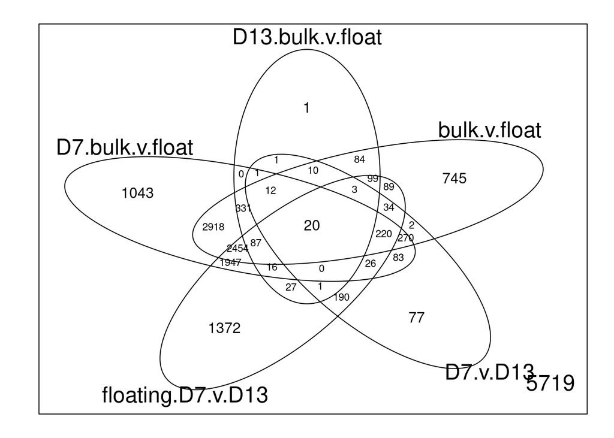

```r
vennDiagram(results)
```

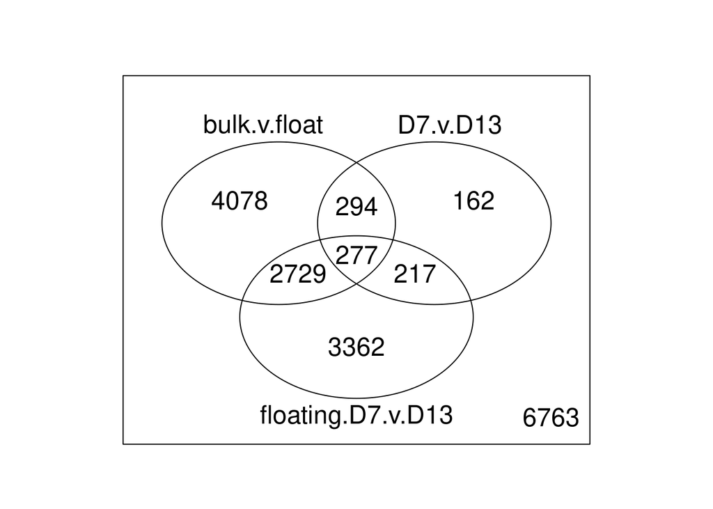

```r
vennDiagram(results[,3:5])
```

If we adjust the pvalues as if this was one test, we spread the significant genes more evenly between the conditions. It’s worth being a little more stringent on the pvalue threshold as well, considering how many D7 genes are showing up.

```r
stringent = decideTests(simple_fit, method="global", adjust.method = "BH", p.value = 0.01)
summary(stringent)
```

```
##        D7.bulk.v.float D13.bulk.v.float bulk.v.float D7.v.D13 floating.D7.v.D13
## Down              2208              304         1978      399              1068
## NotSig           13710            17383        14496    17186             16028
## Up                1964              195         1408      297               786
```

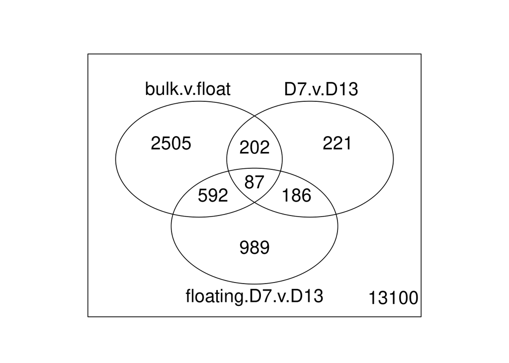

```r
vennDiagram(stringent[,3:5])
```

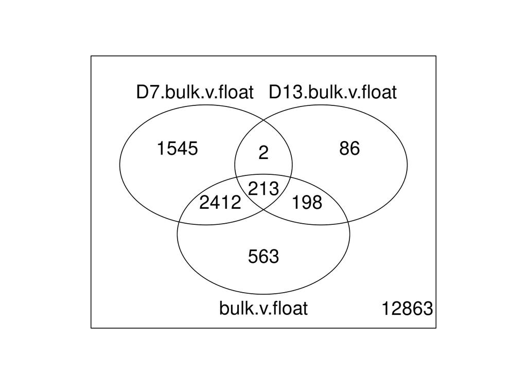

```r
vennDiagram(stringent[,1:3])
```

## Make a combined table

In an ANOVA-style combined test 4.5k genes are different between bulk and floating (not shown). Instead I opted for the combined test, which presents 4.1k DE genes at a 0.01 pvalue threshold.

Top gene preferentially expressed in bulk samples is MEG3, a potential lncRNA tumor supressor, via proliferation control. Another top gene is WEE1, a negative regulator of mitosis entry. There is also CDH11. These genes are also pretty highly expressed.

Genes preferentially expressed in floating adipocytes include a lot of TCA cycle and metabolism genes. Though not in the top 10 galectin 12 is expressed by floating adipocytes, as well as some other galectins.

```r
common = topTable(simple_fit, coef = "bulk.v.float", number=nrow(simple_fit$genes))
head(common[3:ncol(common)], n=10) #bulk genes
```

```
##                 gene_name
## ENSG00000214548      MEG3
## ENSG00000059804    SLC2A3
## ENSG00000135318      NT5E
## ENSG00000163661      PTX3
## ENSG00000172716    SLFN11
## ENSG00000166483      WEE1
## ENSG00000235770 LINC00607
## ENSG00000140937     CDH11
## ENSG00000069535      MAOB
## ENSG00000115380    EFEMP1
##                                                            description
## ENSG00000214548                                maternally expressed 3
## ENSG00000059804                      solute carrier family 2 member 3
## ENSG00000135318                                  5'-nucleotidase ecto
## ENSG00000163661                                           pentraxin 3
## ENSG00000172716                             schlafen family member 11
## ENSG00000166483                             WEE1 G2 checkpoint kinase
## ENSG00000235770            long intergenic non-protein coding RNA 607
## ENSG00000140937                                           cadherin 11
## ENSG00000069535                                   monoamine oxidase B
## ENSG00000115380 EGF containing fibulin extracellular matrix protein 1
##                   gene_biotype     logFC  AveExpr         t      P.Value
## ENSG00000214548        lincRNA -9.633367 4.930369 -12.79926 1.254808e-08
## ENSG00000059804 protein_coding -3.893367 4.450288 -12.53753 1.432461e-08
## ENSG00000135318 protein_coding -3.627524 5.556880 -12.36862 1.671937e-08
## ENSG00000163661 protein_coding -3.770692 9.850227 -12.27791 1.987216e-08
## ENSG00000172716 protein_coding -3.867124 4.074533 -12.23848 1.883417e-08
## ENSG00000166483 protein_coding -3.176580 3.993851 -11.98935 2.314855e-08
## ENSG00000235770        lincRNA -4.591394 1.602233 -12.16860 1.939781e-08
## ENSG00000140937 protein_coding -3.937758 7.160479 -11.68409 3.668827e-08
## ENSG00000069535 protein_coding  2.958731 4.715113  11.53557 3.658506e-08
## ENSG00000115380 protein_coding -3.376068 8.219264 -11.38710 4.758911e-08
##                    adj.P.Val         B
## ENSG00000214548 5.913461e-05 10.156846
## ENSG00000059804 5.913461e-05 10.082682
## ENSG00000135318 5.913461e-05  9.980404
## ENSG00000163661 5.913461e-05  9.829568
## ENSG00000172716 5.913461e-05  9.808846
## ENSG00000166483 5.913461e-05  9.617041
## ENSG00000235770 5.913461e-05  9.419036
## ENSG00000140937 7.289551e-05  9.266695
## ENSG00000069535 7.289551e-05  9.239335
## ENSG00000115380 7.352105e-05  9.017122
```

```r
head(common[common$logFC > 0,3:ncol(common)], n=10)
```

```
##                 gene_name
## ENSG00000069535      MAOB
## ENSG00000114054      PCCB
## ENSG00000077420   APBB1IP
## ENSG00000109107     ALDOC
## ENSG00000160752      FDPS
## ENSG00000143149   ALDH9A1
## ENSG00000104325     DECR1
## ENSG00000158571    PFKFB1
## ENSG00000278540     ACACA
## ENSG00000120437     ACAT2
##                                                                                   description
## ENSG00000069535                                                          monoamine oxidase B
## ENSG00000114054                                       propionyl-CoA carboxylase subunit beta
## ENSG00000077420 amyloid beta precursor protein binding family B member 1 interacting protein
## ENSG00000109107                                            aldolase, fructose-bisphosphate C
## ENSG00000160752                                                farnesyl diphosphate synthase
## ENSG00000143149                                    aldehyde dehydrogenase 9 family member A1
## ENSG00000104325                                                  2,4-dienoyl-CoA reductase 1
## ENSG00000158571                        6-phosphofructo-2-kinase/fructose-2,6-biphosphatase 1
## ENSG00000278540                                                 acetyl-CoA carboxylase alpha
## ENSG00000120437                                               acetyl-CoA acetyltransferase 2
##                   gene_biotype    logFC  AveExpr         t      P.Value
## ENSG00000069535 protein_coding 2.958731 4.715113 11.535566 3.658506e-08
## ENSG00000114054 protein_coding 2.397404 6.013270 10.707883 8.775489e-08
## ENSG00000077420 protein_coding 3.088500 7.325403 10.743580 9.202086e-08
## ENSG00000109107 protein_coding 3.776913 5.555454 10.773617 9.410744e-08
## ENSG00000160752 protein_coding 3.479902 9.443267 10.620699 1.109451e-07
## ENSG00000143149 protein_coding 2.358275 8.388481 10.338698 1.319895e-07
## ENSG00000104325 protein_coding 2.397319 7.913023 10.314143 1.356780e-07
## ENSG00000158571 protein_coding 2.627636 4.918301 10.234162 1.484761e-07
## ENSG00000278540 protein_coding 3.104517 8.794839 10.279698 1.581577e-07
## ENSG00000120437 protein_coding 2.856351 7.046501  9.894321 2.388206e-07
##                    adj.P.Val        B
## ENSG00000069535 7.289551e-05 9.239335
## ENSG00000114054 7.352105e-05 8.423523
## ENSG00000077420 7.352105e-05 8.384341
## ENSG00000109107 7.352105e-05 8.359260
## ENSG00000160752 7.352105e-05 8.200432
## ENSG00000143149 7.352105e-05 8.027212
## ENSG00000104325 7.352105e-05 8.001176
## ENSG00000158571 7.506704e-05 7.906557
## ENSG00000278540 7.506704e-05 7.858165
## ENSG00000120437 7.700079e-05 7.455468
```

```r
common[grep("galectin", common$description),]
```

```
##                            gene length gene_name                 description
## ENSG00000133317 ENSG00000133317   2270   LGALS12                galectin 12
## ENSG00000131981 ENSG00000131981   2397    LGALS3                 galectin 3
## ENSG00000168961 ENSG00000168961   5714    LGALS9                 galectin 9
## ENSG00000100097 ENSG00000100097   1099    LGALS1                 galectin 1
## ENSG00000108679 ENSG00000108679   3584  LGALS3BP galectin 3 binding protein
## ENSG00000119862 ENSG00000119862   4003    LGALSL              galectin like
## ENSG00000116977 ENSG00000116977   9710    LGALS8                 galectin 8
##                   gene_biotype       logFC   AveExpr          t      P.Value
## ENSG00000133317 protein_coding  3.24842219  8.361482  9.1688164 5.864689e-07
## ENSG00000131981 protein_coding  1.32498326  6.970505  5.0856727 2.146017e-04
## ENSG00000168961 protein_coding  3.07349954  1.583066  4.4295113 7.186445e-04
## ENSG00000100097 protein_coding  2.10441483 10.029597  2.8892815 1.292895e-02
## ENSG00000108679 protein_coding  1.29332756  7.784121  2.5297310 2.550644e-02
## ENSG00000119862 protein_coding  0.16587060  2.433679  0.3465680 7.345919e-01
## ENSG00000116977 protein_coding -0.09327851  5.666180 -0.2653062 7.950321e-01
##                    adj.P.Val          B
## ENSG00000133317 8.337763e-05  6.5756143
## ENSG00000131981 1.974026e-03  0.6183539
## ENSG00000168961 4.488579e-03 -0.3547616
## ENSG00000100097 3.539719e-02 -3.4271000
## ENSG00000108679 5.847514e-02 -4.1194544
## ENSG00000119862 7.957819e-01 -6.5656407
## ENSG00000116977 8.453302e-01 -6.8240437
```

```r
summary(common$adj.P.Val < 0.01)
```

```
##    Mode   FALSE    TRUE
## logical   13774    4108
```

Add some information about the individual tests as well?

```r
d7 = topTable(simple_fit, coef = "D7.bulk.v.float", number=nrow(simple_fit$genes))

d13 = topTable(simple_fit, coef = "D13.bulk.v.float", number=nrow(simple_fit$genes))

both = merge(d7, d13, suffixes=c("_d7", "_d13"), by=c("gene","length","gene_name","description", "gene_biotype"))
head(both)
```

```
##              gene length gene_name
## 1 ENSG00000000003   4535    TSPAN6
## 2 ENSG00000000005   1610      TNMD
## 3 ENSG00000000419   1207      DPM1
## 4 ENSG00000000457   6883     SCYL3
## 5 ENSG00000000460   5967  C1orf112
## 6 ENSG00000000938   3474       FGR
##                                                    description   gene_biotype
## 1                                               tetraspanin 6  protein_coding
## 2                                                 tenomodulin  protein_coding
## 3 dolichyl-phosphate mannosyltransferase subunit 1, catalytic  protein_coding
## 4                                    SCY1 like pseudokinase 3  protein_coding
## 5                         chromosome 1 open reading frame 112  protein_coding
## 6              FGR proto-oncogene, Src family tyrosine kinase  protein_coding
##      logFC_d7 AveExpr_d7        t_d7   P.Value_d7 adj.P.Val_d7      B_d7
## 1  0.67547430   5.514915  3.89487543 1.872510e-03 0.0069182267 -1.645111
## 2 -0.02997169   0.616374 -0.06191358 9.515956e-01 0.9617064152 -6.408588
## 3 -0.34481733   5.230867 -2.02247538 6.438590e-02 0.1040944560 -5.056931
## 4 -0.22910794   3.348528 -1.12317095 2.818515e-01 0.3559622158 -6.179222
## 5  0.46905196   1.671116  1.95110165 7.312595e-02 0.1158740158 -4.920744
## 6  2.47196326   2.527861  7.51165881 5.095736e-06 0.0001874937  4.464759
##   logFC_d13 AveExpr_d13     t_d13  P.Value_d13 adj.P.Val_d13      B_d13
## 1 0.8405987    5.514915 4.8299570 0.0003367825     0.0286158  0.2992962
## 2 0.3168268    0.616374 0.8607211 0.4053521278     0.6389727 -6.0156622
## 3 0.1961160    5.230867 1.1778541 0.2601463871     0.5047128 -5.9876391
## 4 0.2047768    3.348528 1.0288597 0.3224678841     0.5650197 -6.0196316
## 5 0.5926893    1.671116 2.4166014 0.0312488679     0.1664746 -3.8739835
## 6 0.6055041    2.527861 1.9922708 0.0682922514     0.2482793 -4.6900573
```

```r
all = merge(common, both, by=c("gene","length","gene_name","description", "gene_biotype"))
head(all)
```

```
##              gene length gene_name
## 1 ENSG00000000003   4535    TSPAN6
## 2 ENSG00000000005   1610      TNMD
## 3 ENSG00000000419   1207      DPM1
## 4 ENSG00000000457   6883     SCYL3
## 5 ENSG00000000460   5967  C1orf112
## 6 ENSG00000000938   3474       FGR
##                                                    description   gene_biotype
## 1                                               tetraspanin 6  protein_coding
## 2                                                 tenomodulin  protein_coding
## 3 dolichyl-phosphate mannosyltransferase subunit 1, catalytic  protein_coding
## 4                                    SCY1 like pseudokinase 3  protein_coding
## 5                         chromosome 1 open reading frame 112  protein_coding
## 6              FGR proto-oncogene, Src family tyrosine kinase  protein_coding
##         logFC  AveExpr           t      P.Value    adj.P.Val         B
```

[output cut: 20 more lines]

```r
all = all[grep("^(t.*|B_d.*|P.Value_d.*)", colnames(all), invert=T)]
all = all[order(all$adj.P.Val, -(all$B)),]
head(all)
```

```
##                  gene length gene_name                       description
## 13573 ENSG00000214548  23224      MEG3           maternally expressed 3
## 669   ENSG00000059804   6159    SLC2A3 solute carrier family 2 member 3
## 5648  ENSG00000135318   4533      NT5E             5'-nucleotidase ecto
## 8718  ENSG00000163661   1940      PTX3                      pentraxin 3
## 10268 ENSG00000172716   5982    SLFN11        schlafen family member 11
## 9295  ENSG00000166483   9239      WEE1        WEE1 G2 checkpoint kinase
##         gene_biotype     logFC  AveExpr      P.Value    adj.P.Val         B
## 13573        lincRNA -9.633367 4.930369 1.254808e-08 5.913461e-05 10.156846
## 669   protein_coding -3.893367 4.450288 1.432461e-08 5.913461e-05 10.082682
## 5648  protein_coding -3.627524 5.556880 1.671937e-08 5.913461e-05  9.980404
## 8718  protein_coding -3.770692 9.850227 1.987216e-08 5.913461e-05  9.829568
## 10268 protein_coding -3.867124 4.074533 1.883417e-08 5.913461e-05  9.808846
## 9295  protein_coding -3.176580 3.993851 2.314855e-08 5.913461e-05  9.617041
##        logFC_d7 AveExpr_d7 adj.P.Val_d7  logFC_d13 AveExpr_d13 adj.P.Val_d13
## 13573 -5.960323   4.930369 4.265980e-05 -3.6730440    4.930369    0.01374213
## 669   -2.958328   4.450288 2.504413e-05 -0.9350386    4.450288    0.03474772
## 5648  -3.074848   5.556880 2.078967e-05 -0.5526757    5.556880    0.11857481
## 8718  -3.066278   9.850227 2.078967e-05 -0.7044144    9.850227    0.08250291
## 10268 -3.116012   4.074533 2.504413e-05 -0.7511128    4.074533    0.06438885
## 9295  -3.016260   3.993851 1.869745e-05 -0.1603199    3.993851    0.62390448
```

```r
write.table(all, file.path(limma_dir, "native_bulk.v.float.tab"),
            sep="\t", row.names=F, quote=F)
```

## Quick GO

```r
molsig <- clusterProfiler::read.gmt("/projects/imb-pkbphil/sp/annotations/molsigdb/msigdb.v7.4.symbols.gmt")
head(molsig); nrow(molsig)
```

```
##       ont      gene
## 1 chr1p12     VTCN1
## 2 chr1p12 LINC01525
## 3 chr1p12    MAN1A2
## 4 chr1p12   VPS25P1
## 5 chr1p12    TENT5C
## 6 chr1p12   VDAC2P3
```

```
## [1] 3854442
```

```r
##Pick gene sets to look in bcos all in a lot
prefixes = c("HALLMARK", "KEGG","REACTOME", "WP", "GOBP", "GOCC","GOMF")
colnames(molsig) = c("term","gene")
some.molsig = molsig[gsub("_.*","", molsig$term) %in% prefixes,]
some.molsig$term = factor(some.molsig$term)
table(gsub("_.*","", some.molsig$term))
```

```
##
##     GOBP     GOCC     GOMF HALLMARK     KEGG REACTOME       WP
##   636699    97202   103847     7321    12797    89457    27711
```

Floating adipocytes are largely enriched for mitochondrial metabolism genes, but also 89 adipogenesis genes.

```r
go_up = enricher(gene=common$gene_name[common$logFC > 0 &
                                      common$adj.P.Val < 0.01],
              TERM2GENE = some.molsig,
              minGSSize = 10,
              universe = common$gene_name) #universe all expressed genes
print(head(go_up, n=10)[c(3:7)])
```

```
##                                                                       GeneRatio
## HALLMARK_OXIDATIVE_PHOSPHORYLATION                                     116/1405
## GOCC_MITOCHONDRIAL_PROTEIN_CONTAINING_COMPLEX                          130/1405
## GOCC_MITOCHONDRIAL_MATRIX                                              176/1405
## GOBP_GENERATION_OF_PRECURSOR_METABOLITES_AND_ENERGY                    163/1405
## REACTOME_THE_CITRIC_ACID_TCA_CYCLE_AND_RESPIRATORY_ELECTRON_TRANSPORT   94/1405
## GOBP_CELLULAR_RESPIRATION                                               91/1405
## GOBP_OXIDATIVE_PHOSPHORYLATION                                          78/1405
## GOBP_ENERGY_DERIVATION_BY_OXIDATION_OF_ORGANIC_COMPOUNDS               106/1405
## GOCC_INNER_MITOCHONDRIAL_MEMBRANE_PROTEIN_COMPLEX                       75/1405
## GOBP_MONOCARBOXYLIC_ACID_METABOLIC_PROCESS                             152/1405
##                                                                         BgRatio
## HALLMARK_OXIDATIVE_PHOSPHORYLATION                                    200/12922
## GOCC_MITOCHONDRIAL_PROTEIN_CONTAINING_COMPLEX                         253/12922
## GOCC_MITOCHONDRIAL_MATRIX                                             442/12922
## GOBP_GENERATION_OF_PRECURSOR_METABOLITES_AND_ENERGY                   452/12922
## REACTOME_THE_CITRIC_ACID_TCA_CYCLE_AND_RESPIRATORY_ELECTRON_TRANSPORT 174/12922
## GOBP_CELLULAR_RESPIRATION                                             173/12922
## GOBP_OXIDATIVE_PHOSPHORYLATION                                        135/12922
## GOBP_ENERGY_DERIVATION_BY_OXIDATION_OF_ORGANIC_COMPOUNDS              248/12922
## GOCC_INNER_MITOCHONDRIAL_MEMBRANE_PROTEIN_COMPLEX                     134/12922
## GOBP_MONOCARBOXYLIC_ACID_METABOLIC_PROCESS                            485/12922
##                                                                             pvalue
## HALLMARK_OXIDATIVE_PHOSPHORYLATION                                    2.086118e-60
## GOCC_MITOCHONDRIAL_PROTEIN_CONTAINING_COMPLEX                         3.648471e-59
## GOCC_MITOCHONDRIAL_MATRIX                                             6.540631e-59
## GOBP_GENERATION_OF_PRECURSOR_METABOLITES_AND_ENERGY                   1.363852e-47
## REACTOME_THE_CITRIC_ACID_TCA_CYCLE_AND_RESPIRATORY_ELECTRON_TRANSPORT 2.424884e-45
## GOBP_CELLULAR_RESPIRATION                                             1.251222e-42
## GOBP_OXIDATIVE_PHOSPHORYLATION                                        1.231414e-40
## GOBP_ENERGY_DERIVATION_BY_OXIDATION_OF_ORGANIC_COMPOUNDS              8.766013e-39
## GOCC_INNER_MITOCHONDRIAL_MEMBRANE_PROTEIN_COMPLEX                     8.766996e-38
## GOBP_MONOCARBOXYLIC_ACID_METABOLIC_PROCESS                            5.870673e-36
##                                                                           p.adjust
## HALLMARK_OXIDATIVE_PHOSPHORYLATION                                    1.438587e-56
## GOCC_MITOCHONDRIAL_PROTEIN_CONTAINING_COMPLEX                         1.257993e-55
## GOCC_MITOCHONDRIAL_MATRIX                                             1.503473e-55
## GOBP_GENERATION_OF_PRECURSOR_METABOLITES_AND_ENERGY                   2.351281e-44
## REACTOME_THE_CITRIC_ACID_TCA_CYCLE_AND_RESPIRATORY_ELECTRON_TRANSPORT 3.344401e-42
## GOBP_CELLULAR_RESPIRATION                                             1.438072e-39
## GOBP_OXIDATIVE_PHOSPHORYLATION                                        1.213119e-37
## GOBP_ENERGY_DERIVATION_BY_OXIDATION_OF_ORGANIC_COMPOUNDS              7.556303e-36
## GOCC_INNER_MITOCHONDRIAL_MEMBRANE_PROTEIN_COMPLEX                     6.717467e-35
## GOBP_MONOCARBOXYLIC_ACID_METABOLIC_PROCESS                            4.048416e-33
##                                                                             qvalue
## HALLMARK_OXIDATIVE_PHOSPHORYLATION                                    1.297126e-56
## GOCC_MITOCHONDRIAL_PROTEIN_CONTAINING_COMPLEX                         1.134290e-55
## GOCC_MITOCHONDRIAL_MATRIX                                             1.355632e-55
## GOBP_GENERATION_OF_PRECURSOR_METABOLITES_AND_ENERGY                   2.120073e-44
## REACTOME_THE_CITRIC_ACID_TCA_CYCLE_AND_RESPIRATORY_ELECTRON_TRANSPORT 3.015535e-42
## GOBP_CELLULAR_RESPIRATION                                             1.296662e-39
## GOBP_OXIDATIVE_PHOSPHORYLATION                                        1.093829e-37
## GOBP_ENERGY_DERIVATION_BY_OXIDATION_OF_ORGANIC_COMPOUNDS              6.813268e-36
## GOCC_INNER_MITOCHONDRIAL_MEMBRANE_PROTEIN_COMPLEX                     6.056917e-35
## GOBP_MONOCARBOXYLIC_ACID_METABOLIC_PROCESS                            3.650323e-33
```

```r
go_up[grep("ADIPO", go_up$ID), 3:9]
```

```
##                           GeneRatio   BgRatio       pvalue     p.adjust
## HALLMARK_ADIPOGENESIS       89/1405 196/12922 3.495522e-35 2.008760e-32
## WP_LEPTIN_AND_ADIPONECTIN    5/1405  10/12922 2.377042e-03 3.152323e-02
##                                 qvalue
## HALLMARK_ADIPOGENESIS     1.811232e-32
## WP_LEPTIN_AND_ADIPONECTIN 2.842345e-02
##                                                                                                                                                                                                                                                                                                          …
## HALLMARK_ADIPOGENESIS     DECR1/CAT/PPARG/HADH/CS/CDKN2C/COX7B/QDPR/MGST3/IDH1/LPCAT3/…
## WP_LEPTIN_AND_ADIPONECTIN                                                                                                                                                                                                                                                                                …
##                           Count
## HALLMARK_ADIPOGENESIS        89
## WP_LEPTIN_AND_ADIPONECTIN     5
```

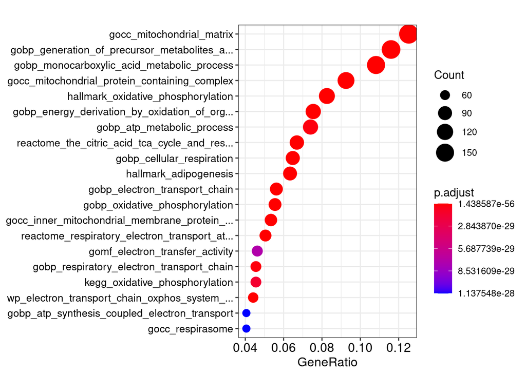

```r
dotplot(go_up, showCategory=20)+ scale_y_discrete(label=function(x) tolower(stringr::str_trunc(x,45))) +
theme(axis.text.y = element_text(size=10))
```

Bulk adipocytes are enriched for a variety of terms, with extracellular matrix very strong (likely driving the epithelial to mesenchymal gene set) as well as blood vessel and connective tissue GO terms. In fact ~8% of significant protein coding genes are related to blood vessel morphogenesis (GeneRatio = 0.08).

```r
go_down = enricher(gene=common$gene_name[common$logFC < 0 &
                                      common$adj.P.Val < 0.01],
              TERM2GENE = some.molsig,
              minGSSize = 10,
              universe = common$gene_name) #universe all expressed genes
print(head(go_down, n=10)[c(3:7)])
```

```
##                                                    GeneRatio   BgRatio
## HALLMARK_EPITHELIAL_MESENCHYMAL_TRANSITION          105/1751 194/12922
## GOBP_EXTERNAL_ENCAPSULATING_STRUCTURE_ORGANIZATION  130/1751 305/12922
## REACTOME_EXTRACELLULAR_MATRIX_ORGANIZATION          101/1751 228/12922
## GOMF_EXTRACELLULAR_MATRIX_STRUCTURAL_CONSTITUENT     71/1751 127/12922
## GOCC_EXTERNAL_ENCAPSULATING_STRUCTURE               137/1751 384/12922
## GOCC_COLLAGEN_CONTAINING_EXTRACELLULAR_MATRIX       114/1751 301/12922
## GOBP_BLOOD_VESSEL_MORPHOGENESIS                     143/1751 484/12922
## GOBP_CONNECTIVE_TISSUE_DEVELOPMENT                   74/1751 193/12922
## GOBP_WOUND_HEALING                                  110/1751 363/12922
## GOBP_RESPONSE_TO_WOUNDING                           127/1751 448/12922
##                                                          pvalue     p.adjust
## HALLMARK_EPITHELIAL_MESENCHYMAL_TRANSITION         1.796980e-41 1.277653e-37
## GOBP_EXTERNAL_ENCAPSULATING_STRUCTURE_ORGANIZATION 1.138952e-36 4.048975e-33
## REACTOME_EXTRACELLULAR_MATRIX_ORGANIZATION         2.430876e-30 5.761176e-27
## GOMF_EXTRACELLULAR_MATRIX_STRUCTURAL_CONSTITUENT   1.459174e-29 2.593681e-26
## GOCC_EXTERNAL_ENCAPSULATING_STRUCTURE              6.436895e-29 9.153264e-26
## GOCC_COLLAGEN_CONTAINING_EXTRACELLULAR_MATRIX      9.038416e-27 1.071052e-23
## GOBP_BLOOD_VESSEL_MORPHOGENESIS                    6.114362e-21 6.210445e-18
## GOBP_CONNECTIVE_TISSUE_DEVELOPMENT                 3.986352e-18 3.542870e-15
## GOBP_WOUND_HEALING                                 3.309617e-17 2.614598e-14
## GOBP_RESPONSE_TO_WOUNDING                          4.352932e-17 3.094934e-14
##                                                          qvalue
## HALLMARK_EPITHELIAL_MESENCHYMAL_TRANSITION         1.032602e-37
## GOBP_EXTERNAL_ENCAPSULATING_STRUCTURE_ORGANIZATION 3.272389e-33
## REACTOME_EXTRACELLULAR_MATRIX_ORGANIZATION         4.656193e-27
## GOMF_EXTRACELLULAR_MATRIX_STRUCTURAL_CONSTITUENT   2.096218e-26
## GOCC_EXTERNAL_ENCAPSULATING_STRUCTURE              7.397686e-26
## GOCC_COLLAGEN_CONTAINING_EXTRACELLULAR_MATRIX      8.656266e-24
## GOBP_BLOOD_VESSEL_MORPHOGENESIS                    5.019294e-18
## GOBP_CONNECTIVE_TISSUE_DEVELOPMENT                 2.863355e-15
## GOBP_WOUND_HEALING                                 2.113123e-14
## GOBP_RESPONSE_TO_WOUNDING                          2.501332e-14
```

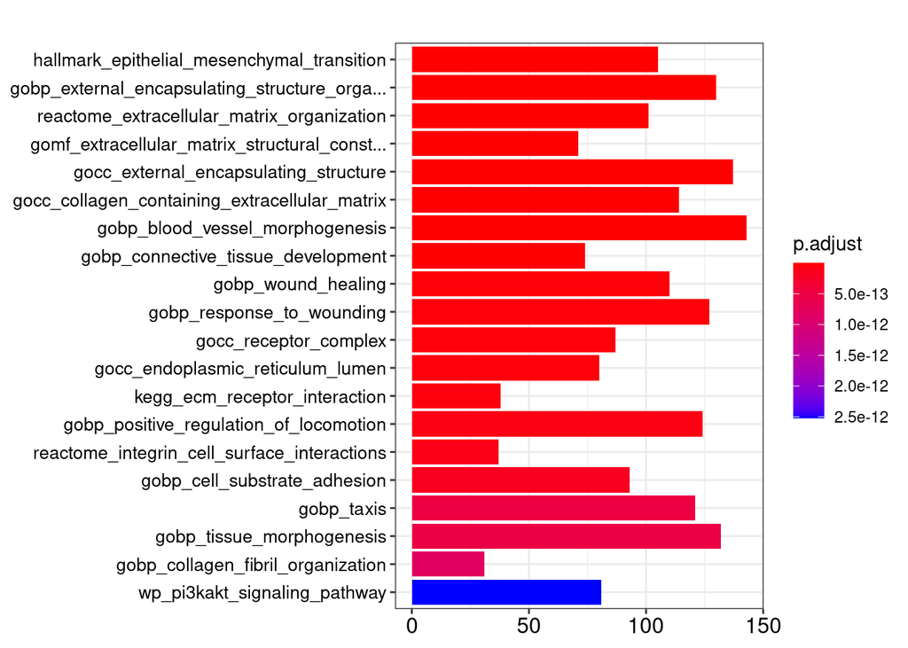

```r
barplot(go_down, showCategory=20)+ scale_x_discrete(label=function(x) tolower(stringr::str_trunc(x,45))) +
theme(axis.text.y = element_text(size=10))
```

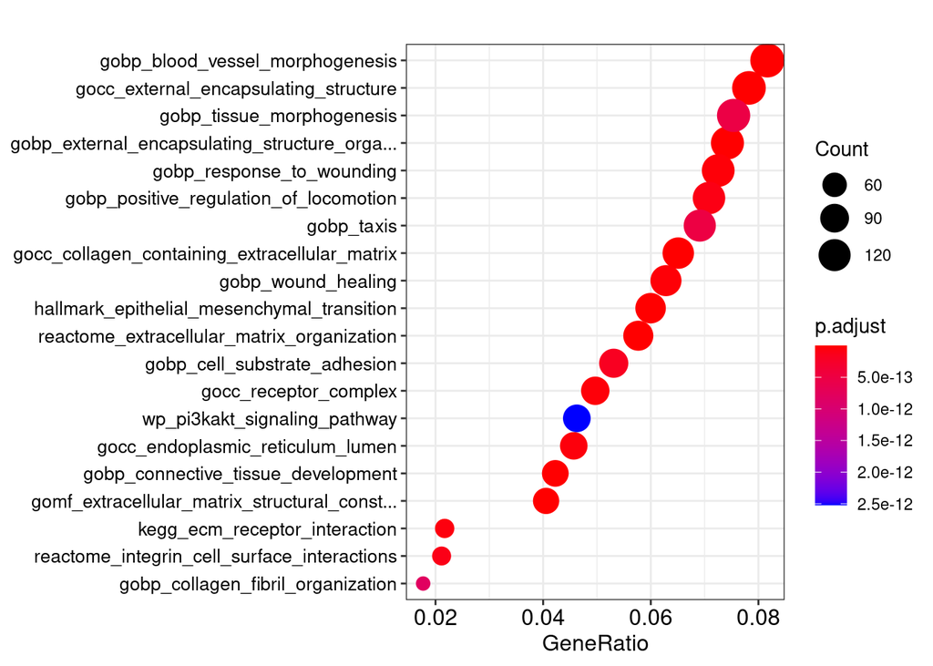

```r
dotplot(go_down, showCategory=20)+ scale_y_discrete(label=function(x) tolower(stringr::str_trunc(x,45))) +
theme(axis.text.y = element_text(size=10))
```

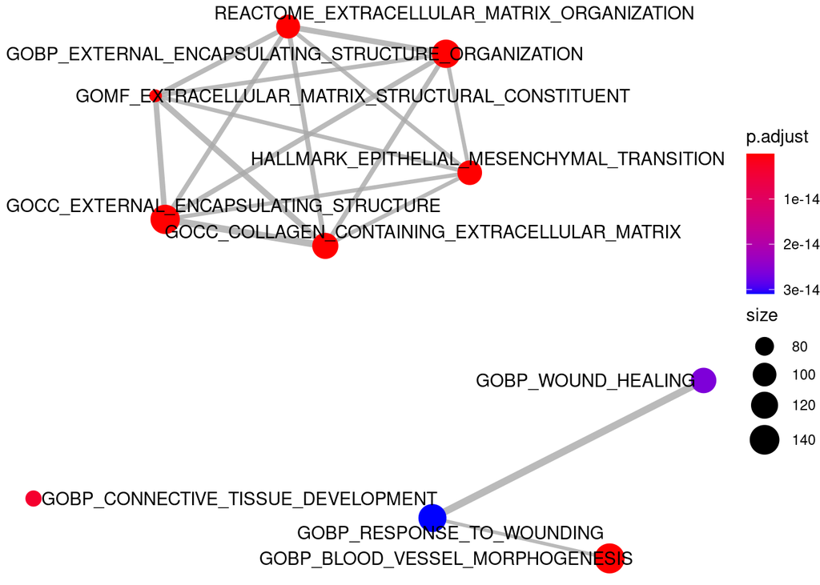

```r
emapplot(go_down, showCategory = 10)
```

```r
go_down[grep("MESENCHYMAL", go_down$ID), 3:9]
```

```
##                                                              GeneRatio
## HALLMARK_EPITHELIAL_MESENCHYMAL_TRANSITION                    105/1751
## GOBP_MESENCHYMAL_CELL_DIFFERENTIATION                          50/1751
## WP_EPITHELIAL_TO_MESENCHYMAL_TRANSITION_IN_COLORECTAL_CANCER   37/1751
## GOBP_MESENCHYMAL_CELL_PROLIFERATION                            13/1751
##                                                                BgRatio
## HALLMARK_EPITHELIAL_MESENCHYMAL_TRANSITION                   194/12922
## GOBP_MESENCHYMAL_CELL_DIFFERENTIATION                        185/12922
## WP_EPITHELIAL_TO_MESENCHYMAL_TRANSITION_IN_COLORECTAL_CANCER 121/12922
## GOBP_MESENCHYMAL_CELL_PROLIFERATION                           34/12922
##                                                                    pvalue
## HALLMARK_EPITHELIAL_MESENCHYMAL_TRANSITION                   1.796980e-41
## GOBP_MESENCHYMAL_CELL_DIFFERENTIATION                        7.951796e-07
## WP_EPITHELIAL_TO_MESENCHYMAL_TRANSITION_IN_COLORECTAL_CANCER 8.700126e-07
## GOBP_MESENCHYMAL_CELL_PROLIFERATION                          2.870155e-04
##                                                                  p.adjust
## HALLMARK_EPITHELIAL_MESENCHYMAL_TRANSITION                   1.277653e-37
## GOBP_MESENCHYMAL_CELL_DIFFERENTIATION                        3.385465e-05
## WP_EPITHELIAL_TO_MESENCHYMAL_TRANSITION_IN_COLORECTAL_CANCER 3.682018e-05
## GOBP_MESENCHYMAL_CELL_PROLIFERATION                          4.388560e-03
##                                                                    qvalue
## HALLMARK_EPITHELIAL_MESENCHYMAL_TRANSITION                   1.032602e-37
## GOBP_MESENCHYMAL_CELL_DIFFERENTIATION                        2.736140e-05
## WP_EPITHELIAL_TO_MESENCHYMAL_TRANSITION_IN_COLORECTAL_CANCER 2.975814e-05
## GOBP_MESENCHYMAL_CELL_PROLIFERATION                          3.546843e-03
##                                                                                                                                                                                                                                                                                                          …
## HALLMARK_EPITHELIAL_MESENCHYMAL_TRANSITION                   NT5E/PTX3/CDH11/WNT5A/THBS2/FSTL1/TPM1/MFAP5/DKK1/SERPINE2/S…
## GOBP_MESENCHYMAL_CELL_DIFFERENTIATION                                                                                                                                                                                                                                                                    …
## WP_EPITHELIAL_TO_MESENCHYMAL_TRANSITION_IN_COLORECTAL_CANCER                                                                                                                                                                                                                                             …
## GOBP_MESENCHYMAL_CELL_PROLIFERATION                                                                                                                                                                                                                                                                      …
##                                                              Count
## HALLMARK_EPITHELIAL_MESENCHYMAL_TRANSITION                     105
## GOBP_MESENCHYMAL_CELL_DIFFERENTIATION                           50
## WP_EPITHELIAL_TO_MESENCHYMAL_TRANSITION_IN_COLORECTAL_CANCER    37
## GOBP_MESENCHYMAL_CELL_PROLIFERATION                             13
```

```r
go_down[grep("EXTRACELLULAR", go_down$ID), 3:9]
```

```
##                                                                                    GeneRatio
## REACTOME_EXTRACELLULAR_MATRIX_ORGANIZATION                                          101/1751
## GOMF_EXTRACELLULAR_MATRIX_STRUCTURAL_CONSTITUENT                                     71/1751
## GOCC_COLLAGEN_CONTAINING_EXTRACELLULAR_MATRIX                                       114/1751
## GOMF_EXTRACELLULAR_MATRIX_BINDING                                                    26/1751
## REACTOME_DEGRADATION_OF_THE_EXTRACELLULAR_MATRIX                                     38/1751
## GOMF_EXTRACELLULAR_MATRIX_STRUCTURAL_CONSTITUENT_CONFERRING_TENSILE_STRENGTH         19/1751
## GOMF_EXTRACELLULAR_MATRIX_STRUCTURAL_CONSTITUENT_CONFERRING_COMPRESSION_RESISTANCE   11/1751
## WP_EXTRACELLULAR_VESICLEMEDIATED_SIGNALING_IN_RECIPIENT_CELLS                        10/1751
## GOBP_EXTRACELLULAR_MATRIX_ASSEMBLY                                                   13/1751
## GOBP_EXTRACELLULAR_REGULATION_OF_SIGNAL_TRANSDUCTION                                  5/1751
##                                                                                      BgRatio
## REACTOME_EXTRACELLULAR_MATRIX_ORGANIZATION                                         228/12922
## GOMF_EXTRACELLULAR_MATRIX_STRUCTURAL_CONSTITUENT                                   127/12922
## GOCC_COLLAGEN_CONTAINING_EXTRACELLULAR_MATRIX                                      301/12922
## GOMF_EXTRACELLULAR_MATRIX_BINDING                                                   49/12922
## REACTOME_DEGRADATION_OF_THE_EXTRACELLULAR_MATRIX                                   100/12922
## GOMF_EXTRACELLULAR_MATRIX_STRUCTURAL_CONSTITUENT_CONFERRING_TENSILE_STRENGTH        33/12922
## GOMF_EXTRACELLULAR_MATRIX_STRUCTURAL_CONSTITUENT_CONFERRING_COMPRESSION_RESISTANCE  14/12922
## WP_EXTRACELLULAR_VESICLEMEDIATED_SIGNALING_IN_RECIPIENT_CELLS                       25/12922
## GOBP_EXTRACELLULAR_MATRIX_ASSEMBLY                                                  40/12922
## GOBP_EXTRACELLULAR_REGULATION_OF_SIGNAL_TRANSDUCTION                                10/12922
##                                                                                          pvalue
## REACTOME_EXTRACELLULAR_MATRIX_ORGANIZATION                                         2.430876e-30
## GOMF_EXTRACELLULAR_MATRIX_STRUCTURAL_CONSTITUENT                                   1.459174e-29
## GOCC_COLLAGEN_CONTAINING_EXTRACELLULAR_MATRIX                                      9.038416e-27
## GOMF_EXTRACELLULAR_MATRIX_BINDING                                                  5.646051e-11
## REACTOME_DEGRADATION_OF_THE_EXTRACELLULAR_MATRIX                                   7.674167e-10
## GOMF_EXTRACELLULAR_MATRIX_STRUCTURAL_CONSTITUENT_CONFERRING_TENSILE_STRENGTH       3.596833e-09
## GOMF_EXTRACELLULAR_MATRIX_STRUCTURAL_CONSTITUENT_CONFERRING_COMPRESSION_RESISTANCE 6.747927e-08
## WP_EXTRACELLULAR_VESICLEMEDIATED_SIGNALING_IN_RECIPIENT_CELLS                      9.550784e-04
## GOBP_EXTRACELLULAR_MATRIX_ASSEMBLY                                                 1.697974e-03
## GOBP_EXTRACELLULAR_REGULATION_OF_SIGNAL_TRANSDUCTION                               6.332024e-03
##                                                                                        p.adjust
## REACTOME_EXTRACELLULAR_MATRIX_ORGANIZATION                                         5.761176e-27
## GOMF_EXTRACELLULAR_MATRIX_STRUCTURAL_CONSTITUENT                                   2.593681e-26
## GOCC_COLLAGEN_CONTAINING_EXTRACELLULAR_MATRIX                                      1.071052e-23
## GOMF_EXTRACELLULAR_MATRIX_BINDING                                                  7.574231e-09
## REACTOME_DEGRADATION_OF_THE_EXTRACELLULAR_MATRIX                                   8.024019e-08
## GOMF_EXTRACELLULAR_MATRIX_STRUCTURAL_CONSTITUENT_CONFERRING_TENSILE_STRENGTH       3.118718e-07
```

[output cut: 22 more lines]

```
## GOMF_EXTRACELLULAR_MATRIX_STRUCTURAL_CONSTITUENT_CONFERRING_COMPRESSION_RESISTANCE                                                                                                                                                                                                                       …
## WP_EXTRACELLULAR_VESICLEMEDIATED_SIGNALING_IN_RECIPIENT_CELLS                                                                                                                                                                                                                                            …
## GOBP_EXTRACELLULAR_MATRIX_ASSEMBLY                                                                                                                                                                                                                                                                       …
## GOBP_EXTRACELLULAR_REGULATION_OF_SIGNAL_TRANSDUCTION                                                                                                                                                                                                                                                     …
##                                                                                    Count
## REACTOME_EXTRACELLULAR_MATRIX_ORGANIZATION                                           101
## GOMF_EXTRACELLULAR_MATRIX_STRUCTURAL_CONSTITUENT                                      71
## GOCC_COLLAGEN_CONTAINING_EXTRACELLULAR_MATRIX                                        114
## GOMF_EXTRACELLULAR_MATRIX_BINDING                                                     26
## REACTOME_DEGRADATION_OF_THE_EXTRACELLULAR_MATRIX                                      38
## GOMF_EXTRACELLULAR_MATRIX_STRUCTURAL_CONSTITUENT_CONFERRING_TENSILE_STRENGTH          19
## GOMF_EXTRACELLULAR_MATRIX_STRUCTURAL_CONSTITUENT_CONFERRING_COMPRESSION_RESISTANCE    11
## WP_EXTRACELLULAR_VESICLEMEDIATED_SIGNALING_IN_RECIPIENT_CELLS                         10
## GOBP_EXTRACELLULAR_MATRIX_ASSEMBLY                                                    13
## GOBP_EXTRACELLULAR_REGULATION_OF_SIGNAL_TRANSDUCTION                                   5
```

```r
go_down[grep("BLOOD_VESSEL", go_down$ID), 3:9]
```

```
##                                                                                     GeneRatio
## GOBP_BLOOD_VESSEL_MORPHOGENESIS                                                      143/1751
## GOBP_BLOOD_VESSEL_ENDOTHELIAL_CELL_MIGRATION                                          30/1751
## GOBP_POSITIVE_REGULATION_OF_BLOOD_VESSEL_ENDOTHELIAL_CELL_MIGRATION                   18/1751
## GOBP_VENOUS_BLOOD_VESSEL_DEVELOPMENT                                                   6/1751
## GOBP_BLOOD_VESSEL_ENDOTHELIAL_CELL_PROLIFERATION_INVOLVED_IN_SPROUTING_ANGIOGENESIS    7/1751
## GOBP_BRANCHING_INVOLVED_IN_BLOOD_VESSEL_MORPHOGENESIS                                  8/1751
##                                                                                       BgRatio
## GOBP_BLOOD_VESSEL_MORPHOGENESIS                                                     484/12922
## GOBP_BLOOD_VESSEL_ENDOTHELIAL_CELL_MIGRATION                                        103/12922
## GOBP_POSITIVE_REGULATION_OF_BLOOD_VESSEL_ENDOTHELIAL_CELL_MIGRATION                  49/12922
## GOBP_VENOUS_BLOOD_VESSEL_DEVELOPMENT                                                 12/12922
## GOBP_BLOOD_VESSEL_ENDOTHELIAL_CELL_PROLIFERATION_INVOLVED_IN_SPROUTING_ANGIOGENESIS  16/12922
## GOBP_BRANCHING_INVOLVED_IN_BLOOD_VESSEL_MORPHOGENESIS                                21/12922
##                                                                                           pvalue
## GOBP_BLOOD_VESSEL_MORPHOGENESIS                                                     6.114362e-21
## GOBP_BLOOD_VESSEL_ENDOTHELIAL_CELL_MIGRATION                                        2.640834e-05
## GOBP_POSITIVE_REGULATION_OF_BLOOD_VESSEL_ENDOTHELIAL_CELL_MIGRATION                 3.840855e-05
## GOBP_VENOUS_BLOOD_VESSEL_DEVELOPMENT                                                2.727905e-03
## GOBP_BLOOD_VESSEL_ENDOTHELIAL_CELL_PROLIFERATION_INVOLVED_IN_SPROUTING_ANGIOGENESIS 3.095192e-03
## GOBP_BRANCHING_INVOLVED_IN_BLOOD_VESSEL_MORPHOGENESIS                               4.414016e-03
##                                                                                         p.adjust
## GOBP_BLOOD_VESSEL_MORPHOGENESIS                                                     6.210445e-18
## GOBP_BLOOD_VESSEL_ENDOTHELIAL_CELL_MIGRATION                                        6.386506e-04
## GOBP_POSITIVE_REGULATION_OF_BLOOD_VESSEL_ENDOTHELIAL_CELL_MIGRATION                 8.575202e-04
## GOBP_VENOUS_BLOOD_VESSEL_DEVELOPMENT                                                2.603253e-02
## GOBP_BLOOD_VESSEL_ENDOTHELIAL_CELL_PROLIFERATION_INVOLVED_IN_SPROUTING_ANGIOGENESIS 2.836314e-02
## GOBP_BRANCHING_INVOLVED_IN_BLOOD_VESSEL_MORPHOGENESIS                               3.731706e-02
##                                                                                           qvalue
## GOBP_BLOOD_VESSEL_MORPHOGENESIS                                                     5.019294e-18
## GOBP_BLOOD_VESSEL_ENDOTHELIAL_CELL_MIGRATION                                        5.161587e-04
## GOBP_POSITIVE_REGULATION_OF_BLOOD_VESSEL_ENDOTHELIAL_CELL_MIGRATION                 6.930495e-04
```

[output cut: 17 more lines]

```r
common[grep("SNAI", common$gene_name),]
```

```
##                            gene length gene_name
## ENSG00000260630 ENSG00000260630   5037 SNAI3-AS1
## ENSG00000019549 ENSG00000019549   3392     SNAI2
## ENSG00000124216 ENSG00000124216   1686     SNAI1
##                                               description   gene_biotype
## ENSG00000260630                    SNAI3 antisense RNA 1       antisense
## ENSG00000019549 snail family transcriptional repressor 2  protein_coding
## ENSG00000124216 snail family transcriptional repressor 1  protein_coding
##                     logFC  AveExpr         t      P.Value    adj.P.Val
## ENSG00000260630  2.944965 3.602903  5.903158 0.0000573521 0.0008821992
## ENSG00000019549 -1.643245 5.743067 -4.517421 0.0006130985 0.0040144369
## ENSG00000124216  1.570253 1.933057  2.346155 0.0359047304 0.0756062635
##                          B
## ENSG00000260630  2.0535178
## ENSG00000019549 -0.4128298
## ENSG00000124216 -4.1715846
```

## Volcanoplots

(-logfc is more expression in bulk adipocytes)

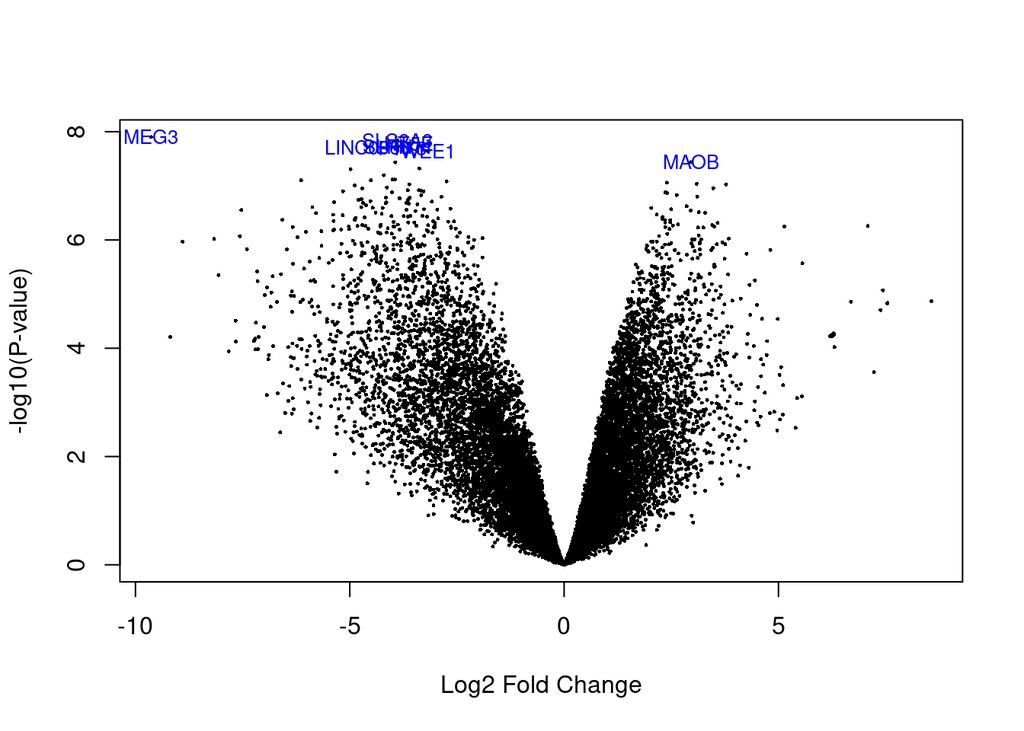

```r
volcanoplot(simple_fit, coef = "bulk.v.float", highlight=8, names = simple_fit$genes$gene_name)
```

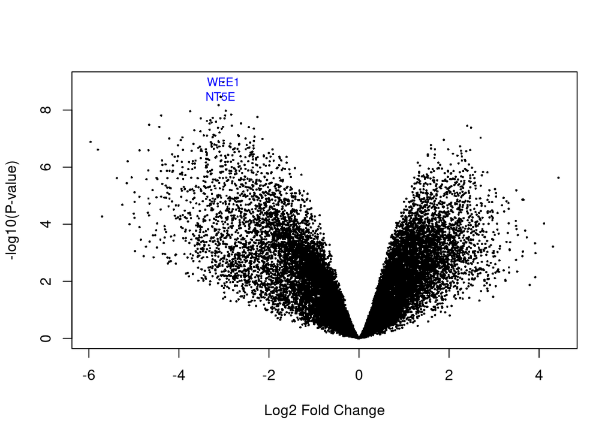

```r
volcanoplot(simple_fit, coef = "D7.bulk.v.float", highlight=2, names = simple_fit$genes$gene_name)
```

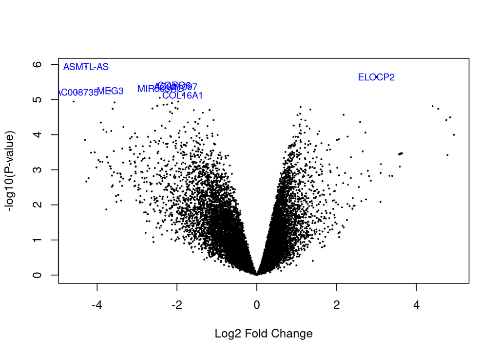

```r
volcanoplot(simple_fit, coef = "D13.bulk.v.float", highlight=8, names = simple_fit$genes$gene_name)
```

## Check p-value distributions

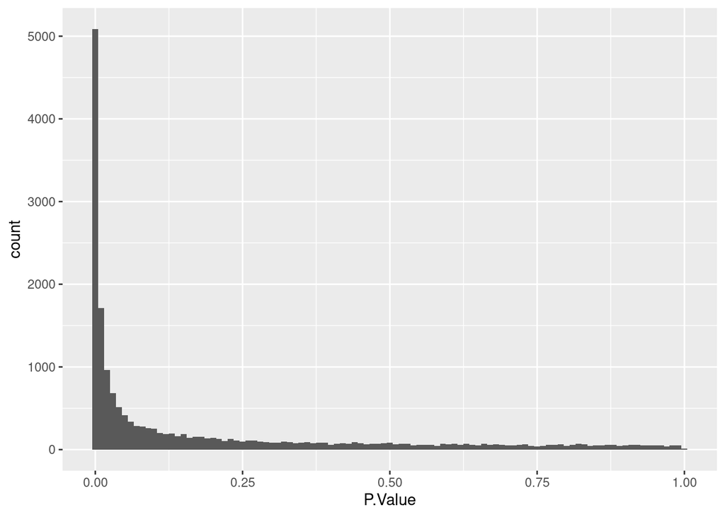

```r
ggplot(common) + geom_histogram(aes(x=P.Value), binwidth=0.01)
```

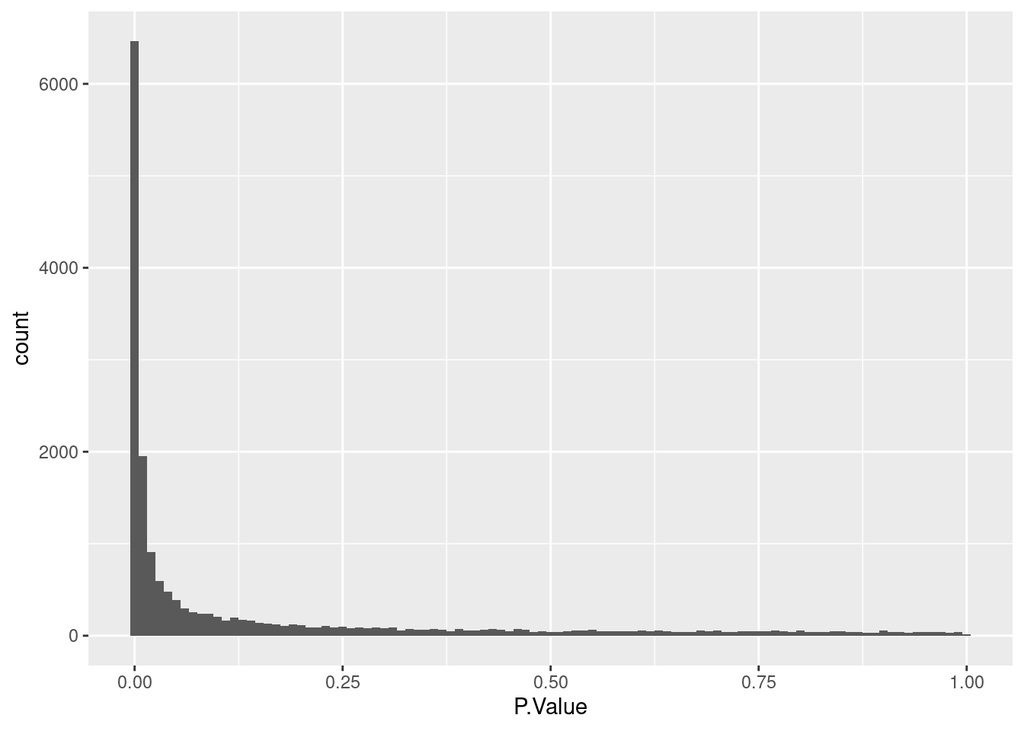

```r
ggplot(d7) + geom_histogram(aes(x=P.Value), binwidth=0.01)
```

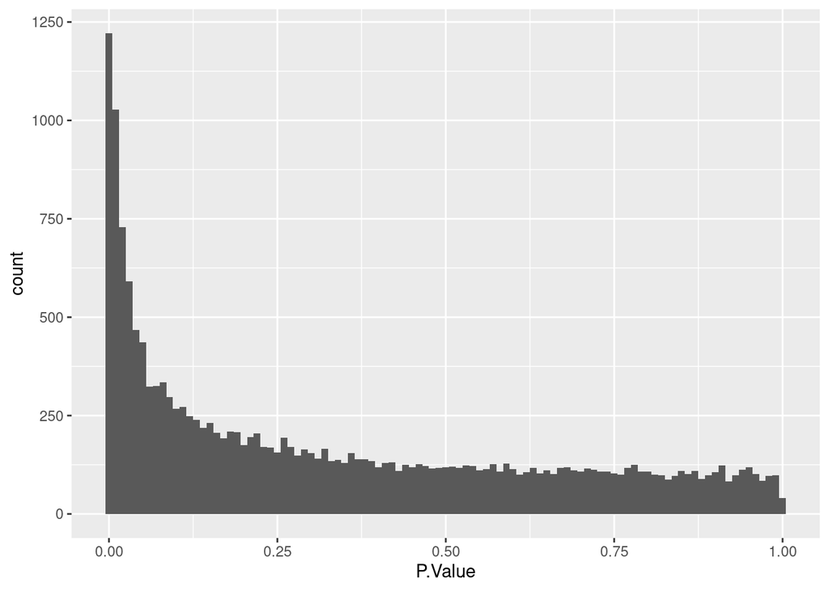

```r
ggplot(d13) + geom_histogram(aes(x=P.Value), binwidth=0.01)
```

## Make FPKM table

```r
lib_rpkm = data.frame(rpkm(filt, normalize.lib.sizes=TRUE))
colnames(lib_rpkm) = paste(filt$samples$bio.condition, filt$samples$rep, sep="_")
lib_rpkm = lib_rpkm[order(colnames(lib_rpkm))]

format_rpkm = merge(filt$genes, lib_rpkm,
                    by.x="gene", by.y = 'row.names',sort=FALSE)
head(format_rpkm)
```

```
##              gene length  gene_name
## 1 ENSG00000227232   1351     WASH7P
## 2 ENSG00000237613   1219    FAM138A
## 3 ENSG00000238009   3726 AL627309.1
## 4 ENSG00000241860   6195 AL627309.5
## 5 ENSG00000279928    570 FO538757.1
## 6 ENSG00000279457   1397     WASH9P
##                                     description           gene_biotype
## 1     WAS protein family homolog 7, pseudogene  unprocessed_pseudogene
## 2 family with sequence similarity 138 member A                 lincRNA
## 3                              novel transcript                lincRNA
## 4                                                 processed_transcript
## 5     DEAD/H-box helicase 11 (DDX11) pseudogene unprocessed_pseudogene
## 6     WAS protein family homolog 9, pseudogene  unprocessed_pseudogene
##      D07G_P7  D07G_P8_1  D07G_P8_2 D07G.floating_P6 D07G.floating_P8_1
```

[output cut: 20 more lines]

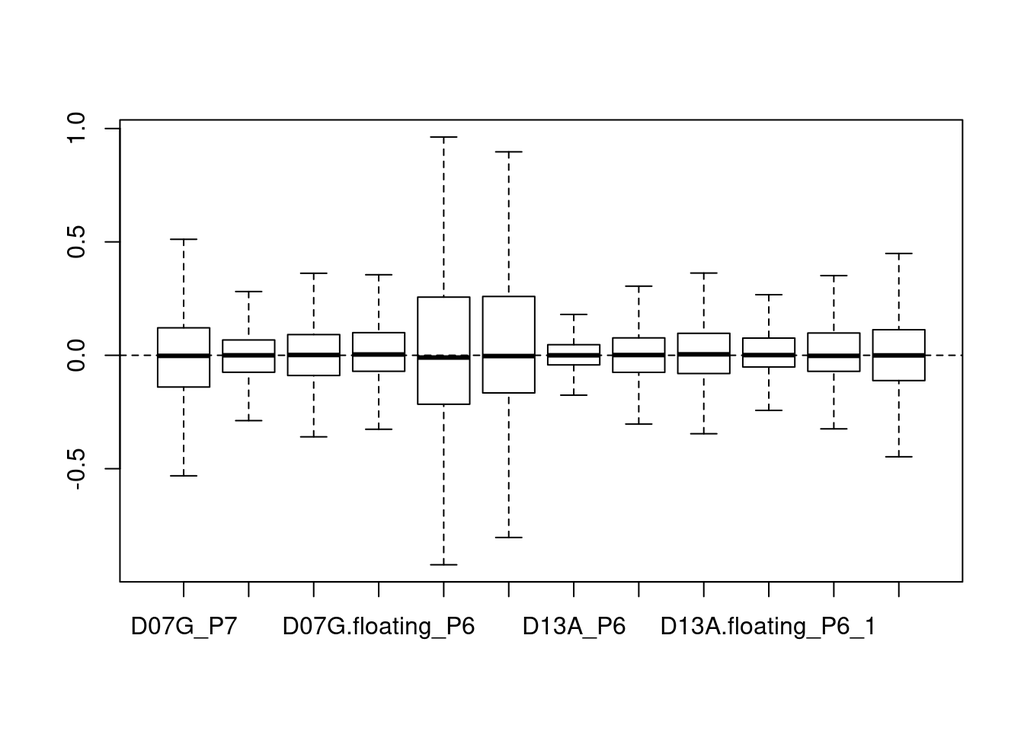

```r
plotRLE(data.matrix(format_rpkm[6:ncol(format_rpkm)]), outline=FALSE)  #check normalisation
```

```r
write.table(format_rpkm, sep='\t', row.names = FALSE,quote = F,
            file=file.path(limma_dir,"native_rpkm_tmm.tab"))
```

```r
filt$samples$group = factor(filt$samples$group)
group_rpkm = data.frame(rpkmByGroup(filt,normalize.lib.sizes=TRUE))
head(group_rpkm)
```

```
##                       D07G D07G.floating        D13A D13A.floating
## ENSG00000227232 1.45284311    1.65573754 2.245384394    0.97633187
## ENSG00000237613 0.24435233    0.25842978 0.002783267    0.00000000
## ENSG00000238009 0.04671288    0.02321488 0.044218332    0.03085716
## ENSG00000241860 0.08916137    0.05562379 0.104887840    0.06130472
## ENSG00000279928 0.02871359    0.01908942 0.420834044    0.44043838
## ENSG00000279457 1.83942667    2.54834721 2.497251307    1.01370838
```

```r
colSums(group_rpkm)
```

```
##          D07G D07G.floating          D13A D13A.floating
##      300156.2      524280.4      307855.6      389362.3
```

```r
format_grpkm = merge(filt$genes, group_rpkm,
                    by.x="gene", by.y = 'row.names',sort=FALSE)
head(format_grpkm)
```

```
##              gene length  gene_name
## 1 ENSG00000227232   1351     WASH7P
## 2 ENSG00000237613   1219    FAM138A
## 3 ENSG00000238009   3726 AL627309.1
## 4 ENSG00000241860   6195 AL627309.5
## 5 ENSG00000279928    570 FO538757.1
## 6 ENSG00000279457   1397     WASH9P
##                                     description           gene_biotype
## 1     WAS protein family homolog 7, pseudogene  unprocessed_pseudogene
## 2 family with sequence similarity 138 member A                 lincRNA
## 3                              novel transcript                lincRNA
## 4                                                 processed_transcript
## 5     DEAD/H-box helicase 11 (DDX11) pseudogene unprocessed_pseudogene
## 6     WAS protein family homolog 9, pseudogene  unprocessed_pseudogene
##         D07G D07G.floating        D13A D13A.floating
## 1 1.45284311    1.65573754 2.245384394    0.97633187
## 2 0.24435233    0.25842978 0.002783267    0.00000000
## 3 0.04671288    0.02321488 0.044218332    0.03085716
## 4 0.08916137    0.05562379 0.104887840    0.06130472
## 5 0.02871359    0.01908942 0.420834044    0.44043838
## 6 1.83942667    2.54834721 2.497251307    1.01370838
```

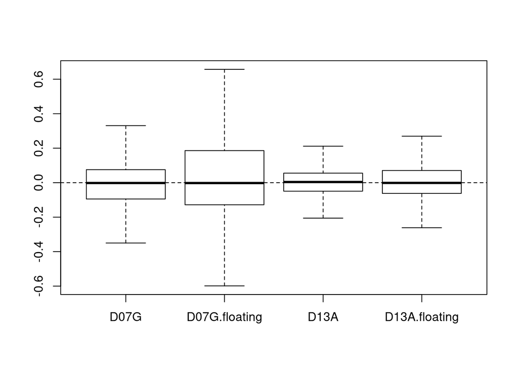

```r
plotRLE(data.matrix(format_grpkm[6:ncol(format_grpkm)]), outline=FALSE)
```

```r
write.table(format_grpkm, sep='\t', row.names = FALSE, quote=F,
            file=file.path(limma_dir,"native_rpkm_tmm_means.tab"))
```